# Risk Factor Analysis

## Outcome Variable

**Outcome Variable:** y_rate_len

## Predictor Variables

**Intervention Variable:** hfoodsec

**Adjustment Set:**

unadjusted

## Stratifying Variables

The analysis was stratified on these variable(s):

- agecat
- studyid
- country

## Data Summary

| agecat | studyid | country | hfoodsec | n_cell | n |
| --- | --- | --- | --- | --- | --- |
| 0-3 months | ki0047075b-MAL-ED | BANGLADESH | Food Secure | 160 | 192 |
| 0-3 months | ki0047075b-MAL-ED | BANGLADESH | Mildly Food Insecure | 4 | 192 |
| 0-3 months | ki0047075b-MAL-ED | BANGLADESH | Food Insecure | 28 | 192 |
| 0-3 months | ki0047075b-MAL-ED | BRAZIL | Food Secure | 0 | 105 |
| 0-3 months | ki0047075b-MAL-ED | BRAZIL | Mildly Food Insecure | 11 | 105 |
| 0-3 months | ki0047075b-MAL-ED | BRAZIL | Food Insecure | 94 | 105 |
| 0-3 months | ki0047075b-MAL-ED | INDIA | Food Secure | 157 | 173 |
| 0-3 months | ki0047075b-MAL-ED | INDIA | Mildly Food Insecure | 2 | 173 |
| 0-3 months | ki0047075b-MAL-ED | INDIA | Food Insecure | 14 | 173 |
| 0-3 months | ki0047075b-MAL-ED | NEPAL | Food Secure | 77 | 100 |
| 0-3 months | ki0047075b-MAL-ED | NEPAL | Mildly Food Insecure | 9 | 100 |
| 0-3 months | ki0047075b-MAL-ED | NEPAL | Food Insecure | 14 | 100 |
| 0-3 months | ki0047075b-MAL-ED | PERU | Food Secure | 27 | 107 |
| 0-3 months | ki0047075b-MAL-ED | PERU | Mildly Food Insecure | 26 | 107 |
| 0-3 months | ki0047075b-MAL-ED | PERU | Food Insecure | 54 | 107 |
| 0-3 months | ki0047075b-MAL-ED | SOUTH AFRICA | Food Secure | 106 | 193 |
| 0-3 months | ki0047075b-MAL-ED | SOUTH AFRICA | Mildly Food Insecure | 17 | 193 |
| 0-3 months | ki0047075b-MAL-ED | SOUTH AFRICA | Food Insecure | 70 | 193 |
| 0-3 months | ki1017093-NIH-Birth | BANGLADESH | Food Secure | 83 | 566 |
| 0-3 months | ki1017093-NIH-Birth | BANGLADESH | Mildly Food Insecure | 444 | 566 |
| 0-3 months | ki1017093-NIH-Birth | BANGLADESH | Food Insecure | 39 | 566 |
| 0-3 months | ki1017093c-NIH-Crypto | BANGLADESH | Food Secure | 427 | 720 |
| 0-3 months | ki1017093c-NIH-Crypto | BANGLADESH | Mildly Food Insecure | 207 | 720 |
| 0-3 months | ki1017093c-NIH-Crypto | BANGLADESH | Food Insecure | 86 | 720 |
| 0-3 months | kiGH5241-JiVitA-3 | BANGLADESH | Food Secure | 12992 | 26316 |
| 0-3 months | kiGH5241-JiVitA-3 | BANGLADESH | Mildly Food Insecure | 8848 | 26316 |
| 0-3 months | kiGH5241-JiVitA-3 | BANGLADESH | Food Insecure | 4476 | 26316 |
| 0-3 months | kiGH5241-JiVitA-4 | BANGLADESH | Food Secure | 1828 | 3592 |
| 0-3 months | kiGH5241-JiVitA-4 | BANGLADESH | Mildly Food Insecure | 1268 | 3592 |
| 0-3 months | kiGH5241-JiVitA-4 | BANGLADESH | Food Insecure | 496 | 3592 |

[output cut: 99 more lines]

The following strata were considered:

- agecat: 0-3 months, studyid: ki0047075b-MAL-ED, country: BANGLADESH
- agecat: 0-3 months, studyid: ki0047075b-MAL-ED, country: BRAZIL
- agecat: 0-3 months, studyid: ki0047075b-MAL-ED, country: INDIA
- agecat: 0-3 months, studyid: ki0047075b-MAL-ED, country: NEPAL
- agecat: 0-3 months, studyid: ki0047075b-MAL-ED, country: PERU
- agecat: 0-3 months, studyid: ki0047075b-MAL-ED, country: SOUTH AFRICA
- agecat: 0-3 months, studyid: ki1017093-NIH-Birth, country: BANGLADESH
- agecat: 0-3 months, studyid: ki1017093c-NIH-Crypto, country: BANGLADESH
- agecat: 0-3 months, studyid: kiGH5241-JiVitA-3, country: BANGLADESH
- agecat: 0-3 months, studyid: kiGH5241-JiVitA-4, country: BANGLADESH
- agecat: 12-24 months, studyid: ki0047075b-MAL-ED, country: BANGLADESH
- agecat: 12-24 months, studyid: ki0047075b-MAL-ED, country: BRAZIL
- agecat: 12-24 months, studyid: ki0047075b-MAL-ED, country: INDIA
- agecat: 12-24 months, studyid: ki0047075b-MAL-ED, country: NEPAL
- agecat: 12-24 months, studyid: ki0047075b-MAL-ED, country: PERU
- agecat: 12-24 months, studyid: ki0047075b-MAL-ED, country: SOUTH AFRICA
- agecat: 12-24 months, studyid: ki1017093-NIH-Birth, country: BANGLADESH
- agecat: 12-24 months, studyid: ki1017093c-NIH-Crypto, country: BANGLADESH
- agecat: 12-24 months, studyid: ki1113344-GMS-Nepal, country: NEPAL
- agecat: 12-24 months, studyid: kiGH5241-JiVitA-3, country: BANGLADESH
- agecat: 12-24 months, studyid: kiGH5241-JiVitA-4, country: BANGLADESH
- agecat: 3-6 months, studyid: ki0047075b-MAL-ED, country: BANGLADESH
- agecat: 3-6 months, studyid: ki0047075b-MAL-ED, country: BRAZIL
- agecat: 3-6 months, studyid: ki0047075b-MAL-ED, country: INDIA
- agecat: 3-6 months, studyid: ki0047075b-MAL-ED, country: NEPAL
- agecat: 3-6 months, studyid: ki0047075b-MAL-ED, country: PERU
- agecat: 3-6 months, studyid: ki0047075b-MAL-ED, country: SOUTH AFRICA
- agecat: 3-6 months, studyid: ki1017093-NIH-Birth, country: BANGLADESH
- agecat: 3-6 months, studyid: ki1017093c-NIH-Crypto, country: BANGLADESH
- agecat: 3-6 months, studyid: ki1113344-GMS-Nepal, country: NEPAL
- agecat: 3-6 months, studyid: kiGH5241-JiVitA-3, country: BANGLADESH
- agecat: 3-6 months, studyid: kiGH5241-JiVitA-4, country: BANGLADESH
- agecat: 6-12 months, studyid: ki0047075b-MAL-ED, country: BANGLADESH
- agecat: 6-12 months, studyid: ki0047075b-MAL-ED, country: BRAZIL
- agecat: 6-12 months, studyid: ki0047075b-MAL-ED, country: INDIA
- agecat: 6-12 months, studyid: ki0047075b-MAL-ED, country: NEPAL
- agecat: 6-12 months, studyid: ki0047075b-MAL-ED, country: PERU
- agecat: 6-12 months, studyid: ki0047075b-MAL-ED, country: SOUTH AFRICA
- agecat: 6-12 months, studyid: ki1017093-NIH-Birth, country: BANGLADESH
- agecat: 6-12 months, studyid: ki1017093c-NIH-Crypto, country: BANGLADESH
- agecat: 6-12 months, studyid: ki1113344-GMS-Nepal, country: NEPAL
- agecat: 6-12 months, studyid: kiGH5241-JiVitA-3, country: BANGLADESH
- agecat: 6-12 months, studyid: kiGH5241-JiVitA-4, country: BANGLADESH

### Dropped Strata

Some strata were dropped due to rare outcomes:

- agecat: 0-3 months, studyid: ki0047075b-MAL-ED, country: BANGLADESH
- agecat: 0-3 months, studyid: ki0047075b-MAL-ED, country: BRAZIL
- agecat: 0-3 months, studyid: ki0047075b-MAL-ED, country: INDIA
- agecat: 3-6 months, studyid: ki0047075b-MAL-ED, country: BANGLADESH
- agecat: 3-6 months, studyid: ki0047075b-MAL-ED, country: BRAZIL
- agecat: 6-12 months, studyid: ki0047075b-MAL-ED, country: BANGLADESH
- agecat: 6-12 months, studyid: ki0047075b-MAL-ED, country: BRAZIL
- agecat: 12-24 months, studyid: ki0047075b-MAL-ED, country: BANGLADESH
- agecat: 12-24 months, studyid: ki0047075b-MAL-ED, country: BRAZIL

## Methods Detail

We’re interested in the causal parameters $E[Y_a]$ for all values of $a \in \mathcal{A}$. These parameters represent the mean outcome if, possibly contrary to fact, we intervened to set all units to have $A=a$. Under the randomization and positivity assumptions, these are identified by the statistical parameters $\psi_a=E_W[E_{Y|A,W}(Y|A=a,W)]$. In addition, we’re interested in the mean of $Y$, $E[Y]$ under no intervention (the observed mean). We will estimate these parameters by using SuperLearner to fit the relevant likelihood factors – $E_{Y|A,W}(Y|A=a,W)$ and $p(A=a|W)$, and then updating our likelihood fit using a joint TMLE.

For unadjusted analyses ($W=\{\}$), initial likelihoods were estimated using Lrnr_glm to estimate the simple $E(Y|A)$ and Lrnr_mean to estimate $p(A)$. For adjusted analyses, a small library containing Lrnr_glmnet, Lrnr_xgboost, and Lrnr_mean was used.

Having estimated these parameters, we will then use the delta method to estimate relative risks and attributable risks relative to a prespecified baseline level of $A$.

# Results Detail

## Results Plots

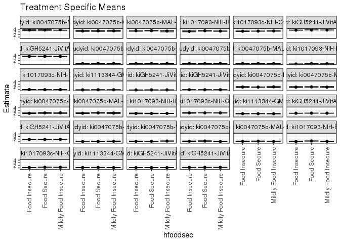

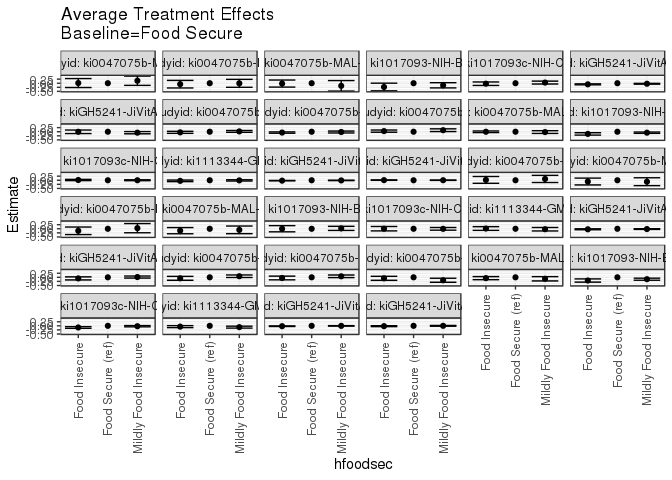

## Results Table

### Parameter: TSM

| agecat | studyid | country | intervention_level | baseline_level | estimate | ci_lower | ci_upper |
| --- | --- | --- | --- | --- | --- | --- | --- |
| 0-3 months | ki0047075b-MAL-ED | NEPAL | Food Secure | NA | 3.7191675 | 3.6014887 | 3.8368464 |
| 0-3 months | ki0047075b-MAL-ED | NEPAL | Mildly Food Insecure | NA | 3.8722349 | 3.6130036 | 4.1314662 |
| 0-3 months | ki0047075b-MAL-ED | NEPAL | Food Insecure | NA | 3.7296049 | 3.4811114 | 3.9780985 |
| 0-3 months | ki0047075b-MAL-ED | PERU | Food Secure | NA | 3.3863896 | 3.1984358 | 3.5743435 |
| 0-3 months | ki0047075b-MAL-ED | PERU | Mildly Food Insecure | NA | 3.3789941 | 3.2244810 | 3.5335072 |
| 0-3 months | ki0047075b-MAL-ED | PERU | Food Insecure | NA | 3.3272082 | 3.1922064 | 3.4622100 |
| 0-3 months | ki0047075b-MAL-ED | SOUTH AFRICA | Food Secure | NA | 3.4630577 | 3.3436425 | 3.5824729 |
| 0-3 months | ki0047075b-MAL-ED | SOUTH AFRICA | Mildly Food Insecure | NA | 3.3022696 | 3.0038121 | 3.6007270 |
| 0-3 months | ki0047075b-MAL-ED | SOUTH AFRICA | Food Insecure | NA | 3.4416797 | 3.2600860 | 3.6232735 |
| 0-3 months | ki1017093-NIH-Birth | BANGLADESH | Food Secure | NA | 3.4288648 | 3.2820555 | 3.5756741 |
| 0-3 months | ki1017093-NIH-Birth | BANGLADESH | Mildly Food Insecure | NA | 3.3014725 | 3.2395868 | 3.3633582 |
| 0-3 months | ki1017093-NIH-Birth | BANGLADESH | Food Insecure | NA | 3.1965703 | 3.0119611 | 3.3811794 |
| 0-3 months | ki1017093c-NIH-Crypto | BANGLADESH | Food Secure | NA | 3.2950371 | 3.2443838 | 3.3456904 |
| 0-3 months | ki1017093c-NIH-Crypto | BANGLADESH | Mildly Food Insecure | NA | 3.3343952 | 3.2624283 | 3.4063622 |
| 0-3 months | ki1017093c-NIH-Crypto | BANGLADESH | Food Insecure | NA | 3.2658439 | 3.1719826 | 3.3597052 |
| 0-3 months | kiGH5241-JiVitA-3 | BANGLADESH | Food Secure | NA | 3.7410012 | 3.7259325 | 3.7560699 |
| 0-3 months | kiGH5241-JiVitA-3 | BANGLADESH | Mildly Food Insecure | NA | 3.7082767 | 3.6895157 | 3.7270376 |
| 0-3 months | kiGH5241-JiVitA-3 | BANGLADESH | Food Insecure | NA | 3.6723346 | 3.6439165 | 3.7007528 |
| 0-3 months | kiGH5241-JiVitA-4 | BANGLADESH | Food Secure | NA | 3.6600913 | 3.6158179 | 3.7043646 |
| 0-3 months | kiGH5241-JiVitA-4 | BANGLADESH | Mildly Food Insecure | NA | 3.6019640 | 3.5519398 | 3.6519882 |
| 0-3 months | kiGH5241-JiVitA-4 | BANGLADESH | Food Insecure | NA | 3.6568637 | 3.5566386 | 3.7570887 |
| 3-6 months | ki0047075b-MAL-ED | INDIA | Food Secure | NA | 1.8945183 | 1.8241876 | 1.9648491 |
| 3-6 months | ki0047075b-MAL-ED | INDIA | Mildly Food Insecure | NA | 1.9760085 | 1.7694994 | 2.1825176 |
| 3-6 months | ki0047075b-MAL-ED | INDIA | Food Insecure | NA | 1.9164151 | 1.7198889 | 2.1129413 |
| 3-6 months | ki0047075b-MAL-ED | NEPAL | Food Secure | NA | 1.9629021 | 1.8751370 | 2.0506671 |
| 3-6 months | ki0047075b-MAL-ED | NEPAL | Mildly Food Insecure | NA | 1.8747213 | 1.6510811 | 2.0983615 |
| 3-6 months | ki0047075b-MAL-ED | NEPAL | Food Insecure | NA | 1.8858286 | 1.6967477 | 2.0749095 |
| 3-6 months | ki0047075b-MAL-ED | PERU | Food Secure | NA | 2.0055653 | 1.8227743 | 2.1883563 |
| 3-6 months | ki0047075b-MAL-ED | PERU | Mildly Food Insecure | NA | 2.0435365 | 1.8294004 | 2.2576725 |
| 3-6 months | ki0047075b-MAL-ED | PERU | Food Insecure | NA | 1.8824371 | 1.7410614 | 2.0238128 |

[output cut: 72 more lines]

### Parameter: E(Y)

| agecat | studyid | country | intervention_level | baseline_level | estimate | ci_lower | ci_upper |
| --- | --- | --- | --- | --- | --- | --- | --- |
| 0-3 months | ki0047075b-MAL-ED | NEPAL | NA | NA | 3.7344048 | 3.6342116 | 3.8345980 |
| 0-3 months | ki0047075b-MAL-ED | PERU | NA | NA | 3.3547253 | 3.2634611 | 3.4459896 |
| 0-3 months | ki0047075b-MAL-ED | SOUTH AFRICA | NA | NA | 3.4411414 | 3.3443437 | 3.5379390 |
| 0-3 months | ki1017093-NIH-Birth | BANGLADESH | NA | NA | 3.3129255 | 3.2581305 | 3.3677204 |
| 0-3 months | ki1017093c-NIH-Crypto | BANGLADESH | NA | NA | 3.3028656 | 3.2646714 | 3.3410598 |
| 0-3 months | kiGH5241-JiVitA-3 | BANGLADESH | NA | NA | 3.7183193 | 3.7063844 | 3.7302541 |
| 0-3 months | kiGH5241-JiVitA-4 | BANGLADESH | NA | NA | 3.6391263 | 3.6075490 | 3.6707036 |
| 3-6 months | ki0047075b-MAL-ED | INDIA | NA | NA | 1.8981970 | 1.8329980 | 1.9633960 |
| 3-6 months | ki0047075b-MAL-ED | NEPAL | NA | NA | 1.9409564 | 1.8656649 | 2.0162478 |
| 3-6 months | ki0047075b-MAL-ED | PERU | NA | NA | 1.9530249 | 1.8522017 | 2.0538480 |
| 3-6 months | ki0047075b-MAL-ED | SOUTH AFRICA | NA | NA | 1.9716570 | 1.8866692 | 2.0566449 |
| 3-6 months | ki1017093-NIH-Birth | BANGLADESH | NA | NA | 1.8326915 | 1.7846731 | 1.8807099 |
| 3-6 months | ki1017093c-NIH-Crypto | BANGLADESH | NA | NA | 2.0057973 | 1.9693775 | 2.0422170 |
| 3-6 months | ki1113344-GMS-Nepal | NEPAL | NA | NA | 1.7061500 | 1.6667551 | 1.7455449 |
| 3-6 months | kiGH5241-JiVitA-3 | BANGLADESH | NA | NA | 1.9201098 | 1.9096479 | 1.9305717 |
| 3-6 months | kiGH5241-JiVitA-4 | BANGLADESH | NA | NA | 1.8993572 | 1.8693950 | 1.9293194 |
| 6-12 months | ki0047075b-MAL-ED | INDIA | NA | NA | 1.1157987 | 1.0858838 | 1.1457135 |
| 6-12 months | ki0047075b-MAL-ED | NEPAL | NA | NA | 1.1896753 | 1.1557826 | 1.2235680 |
| 6-12 months | ki0047075b-MAL-ED | PERU | NA | NA | 1.1824866 | 1.1320801 | 1.2328932 |
| 6-12 months | ki0047075b-MAL-ED | SOUTH AFRICA | NA | NA | 1.1940035 | 1.1512681 | 1.2367388 |
| 6-12 months | ki1017093-NIH-Birth | BANGLADESH | NA | NA | 1.1679344 | 1.1454934 | 1.1903754 |
| 6-12 months | ki1017093c-NIH-Crypto | BANGLADESH | NA | NA | 1.2281313 | 1.2106849 | 1.2455776 |
| 6-12 months | ki1113344-GMS-Nepal | NEPAL | NA | NA | 1.1725665 | 1.1528638 | 1.1922692 |
| 6-12 months | kiGH5241-JiVitA-3 | BANGLADESH | NA | NA | 1.1069328 | 1.1001924 | 1.1136731 |
| 6-12 months | kiGH5241-JiVitA-4 | BANGLADESH | NA | NA | 1.2030242 | 1.1926820 | 1.2133664 |
| 12-24 months | ki0047075b-MAL-ED | INDIA | NA | NA | 0.8797987 | 0.8616531 | 0.8979443 |
| 12-24 months | ki0047075b-MAL-ED | NEPAL | NA | NA | 0.8661220 | 0.8471443 | 0.8850997 |
| 12-24 months | ki0047075b-MAL-ED | PERU | NA | NA | 0.8709334 | 0.8403674 | 0.9014995 |
| 12-24 months | ki0047075b-MAL-ED | SOUTH AFRICA | NA | NA | 0.8714362 | 0.8487736 | 0.8940987 |
| 12-24 months | ki1017093-NIH-Birth | BANGLADESH | NA | NA | 0.7513013 | 0.7366996 | 0.7659029 |
| 12-24 months | ki1017093c-NIH-Crypto | BANGLADESH | NA | NA | 0.8755729 | 0.8637860 | 0.8873598 |
| 12-24 months | ki1113344-GMS-Nepal | NEPAL | NA | NA | 0.8385573 | 0.8230446 | 0.8540700 |
| 12-24 months | kiGH5241-JiVitA-3 | BANGLADESH | NA | NA | 0.7967532 | 0.7914510 | 0.8020553 |
| 12-24 months | kiGH5241-JiVitA-4 | BANGLADESH | NA | NA | 0.8496462 | 0.8441968 | 0.8550956 |

### Parameter: ATE

| agecat | studyid | country | intervention_level | baseline_level | estimate | ci_lower | ci_upper |
| --- | --- | --- | --- | --- | --- | --- | --- |
| 0-3 months | ki0047075b-MAL-ED | NEPAL | Food Secure | Food Secure | 0.0000000 | 0.0000000 | 0.0000000 |
| 0-3 months | ki0047075b-MAL-ED | NEPAL | Mildly Food Insecure | Food Secure | 0.1530674 | -0.1316240 | 0.4377588 |
| 0-3 months | ki0047075b-MAL-ED | NEPAL | Food Insecure | Food Secure | 0.0104374 | -0.2645123 | 0.2853872 |
| 0-3 months | ki0047075b-MAL-ED | PERU | Food Secure | Food Secure | 0.0000000 | 0.0000000 | 0.0000000 |
| 0-3 months | ki0047075b-MAL-ED | PERU | Mildly Food Insecure | Food Secure | -0.0073955 | -0.2507080 | 0.2359169 |
| 0-3 months | ki0047075b-MAL-ED | PERU | Food Insecure | Food Secure | -0.0591814 | -0.2905947 | 0.1722319 |
| 0-3 months | ki0047075b-MAL-ED | SOUTH AFRICA | Food Secure | Food Secure | 0.0000000 | 0.0000000 | 0.0000000 |
| 0-3 months | ki0047075b-MAL-ED | SOUTH AFRICA | Mildly Food Insecure | Food Secure | -0.1607882 | -0.4822486 | 0.1606723 |
| 0-3 months | ki0047075b-MAL-ED | SOUTH AFRICA | Food Insecure | Food Secure | -0.0213780 | -0.2387171 | 0.1959611 |
| 0-3 months | ki1017093-NIH-Birth | BANGLADESH | Food Secure | Food Secure | 0.0000000 | 0.0000000 | 0.0000000 |
| 0-3 months | ki1017093-NIH-Birth | BANGLADESH | Mildly Food Insecure | Food Secure | -0.1273923 | -0.2867122 | 0.0319276 |
| 0-3 months | ki1017093-NIH-Birth | BANGLADESH | Food Insecure | Food Secure | -0.2322945 | -0.4681621 | 0.0035730 |
| 0-3 months | ki1017093c-NIH-Crypto | BANGLADESH | Food Secure | Food Secure | 0.0000000 | 0.0000000 | 0.0000000 |
| 0-3 months | ki1017093c-NIH-Crypto | BANGLADESH | Mildly Food Insecure | Food Secure | 0.0393582 | -0.0486475 | 0.1273638 |
| 0-3 months | ki1017093c-NIH-Crypto | BANGLADESH | Food Insecure | Food Secure | -0.0291932 | -0.1358501 | 0.0774638 |
| 0-3 months | kiGH5241-JiVitA-3 | BANGLADESH | Food Secure | Food Secure | 0.0000000 | 0.0000000 | 0.0000000 |
| 0-3 months | kiGH5241-JiVitA-3 | BANGLADESH | Mildly Food Insecure | Food Secure | -0.0327246 | -0.0559293 | -0.0095198 |
| 0-3 months | kiGH5241-JiVitA-3 | BANGLADESH | Food Insecure | Food Secure | -0.0686666 | -0.0988987 | -0.0384344 |
| 0-3 months | kiGH5241-JiVitA-4 | BANGLADESH | Food Secure | Food Secure | 0.0000000 | 0.0000000 | 0.0000000 |
| 0-3 months | kiGH5241-JiVitA-4 | BANGLADESH | Mildly Food Insecure | Food Secure | -0.0581273 | -0.1265327 | 0.0102780 |
| 0-3 months | kiGH5241-JiVitA-4 | BANGLADESH | Food Insecure | Food Secure | -0.0032276 | -0.1121533 | 0.1056981 |
| 3-6 months | ki0047075b-MAL-ED | INDIA | Food Secure | Food Secure | 0.0000000 | 0.0000000 | 0.0000000 |
| 3-6 months | ki0047075b-MAL-ED | INDIA | Mildly Food Insecure | Food Secure | 0.0814901 | -0.1366667 | 0.2996470 |
| 3-6 months | ki0047075b-MAL-ED | INDIA | Food Insecure | Food Secure | 0.0218967 | -0.1868351 | 0.2306286 |
| 3-6 months | ki0047075b-MAL-ED | NEPAL | Food Secure | Food Secure | 0.0000000 | 0.0000000 | 0.0000000 |
| 3-6 months | ki0047075b-MAL-ED | NEPAL | Mildly Food Insecure | Food Secure | -0.0881808 | -0.3284257 | 0.1520642 |
| 3-6 months | ki0047075b-MAL-ED | NEPAL | Food Insecure | Food Secure | -0.0770735 | -0.2855304 | 0.1313834 |
| 3-6 months | ki0047075b-MAL-ED | PERU | Food Secure | Food Secure | 0.0000000 | 0.0000000 | 0.0000000 |
| 3-6 months | ki0047075b-MAL-ED | PERU | Mildly Food Insecure | Food Secure | 0.0379712 | -0.2435724 | 0.3195148 |
| 3-6 months | ki0047075b-MAL-ED | PERU | Food Insecure | Food Secure | -0.1231282 | -0.3542118 | 0.1079554 |

[output cut: 72 more lines]